# Modeling and prediction for movies

## Setup

### Load packages

```r
library(ggplot2)
library(dplyr)
library(statsr)
library(GGally)
```

### Load data

```r
load("~/Dropbox/Pro Development/Stats with R/New Class/Linear and Multiple Regression Class/eaca_movies.Rdata") #load("movies.Rdata")
```

## Part 1: Data

The data on movies released from 1970 to 2014 is taken from the site Rotten Tomatoes, which provides popular rankings for movies along with other information about them, as revealed in the codebook. The sample of 651 movies is randomly sampled, which makes it less than 10% of the movies made but still a large enough sample so that skew conditions may not be too much of an issue. In this case, because the sample size is large enough and randomly sampled, we are able to generalize beyond the sample to the general population for our predictions. Moreover, because this data is observational and not experimental, we cannot claim causality in the data.

As for other issues that we may face in using this data, because this is a website, we do have to contend with the fact that the results are limited to respondents who rated movies on the website, which may not be reflective of members who also rank films but may not be avid internet users (i.e., the non-response bias). Moreover, there does not seem to be the possibility that audience members are limited to voting once, but they could create and login with multiple email accounts to score a movie. Moreover, there might be concern on independence of film scores, especially if people in the same friendship group or household may be rating the same films in similar ways.

## Part 2: Research question

My research question is the following:

Can we build a model that allows us to predict what makes a movie successful if we know other aspects about the movie, such as recipients of Academy Awards, run time, IMDB rating, and critics score?

This question is helpful in trying to figure out what are the characteristics of a well-received movie by the audience. This is not to imply causality, since this is not an experimental study. However, it is interesting to see in what ways critics scores and other variables, such as run time, may be correlated with audience scores since some of these factors could affect movie popularity and sales (especially run time, which has changed over time with many kinds of movies, like the longer run times of action movies).

It is also important to note that we are hoping to find, as an answer to our research question, a full model, rather than the most significant predictors, that can account for the response variable (audience score).

## Part 3: Exploratory data analysis

Before we get into the data, let’s take a look at some histograms of our data to see the spread and distribution. We will look at critics score, run time, audience score (our response variable), and accolades from the Academy Awards (best picture nomination and if the film has an actor, actress, and director who has ever won an Academy Award).

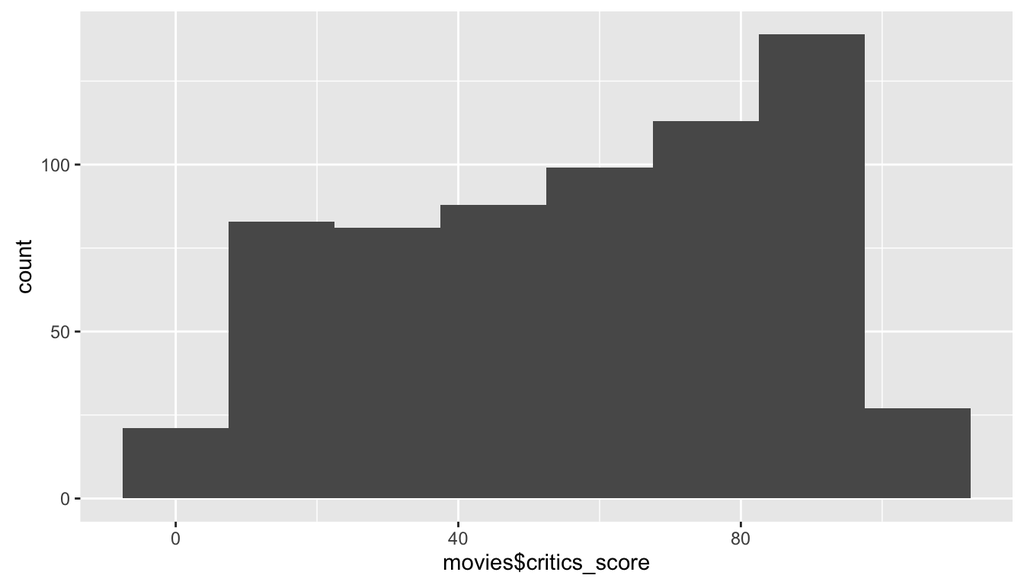

```r
ggplot(data = movies, aes(x = movies$critics_score)) + geom_histogram(binwidth = 15) #histogram of critics score
```

Looking at the histogram, we see that we have a unimodal peak, with some left skew (i.e., asymmetric data) for critics score. Let’s also take at some summary statistics.

```r
summary(movies$critics_score)
```

```
##    Min. 1st Qu.  Median    Mean 3rd Qu.    Max.
##    1.00   33.00   61.00   57.69   83.00  100.00
```

From our summary statistics, we see that the median is greater than the mean, which we would expect because of the left skew. Moreover, we see that only 25% of the movies scored above 83, with the median critics score being 61.

This skew is also reflected in the normal probability plot below, which allows us to see that we have a little bit of a left tail, or some skewing. We also see that, because the line is not entirely straight, we would do well to not assume that this data follows a normal distribution, which is reflected in the histogram as well.

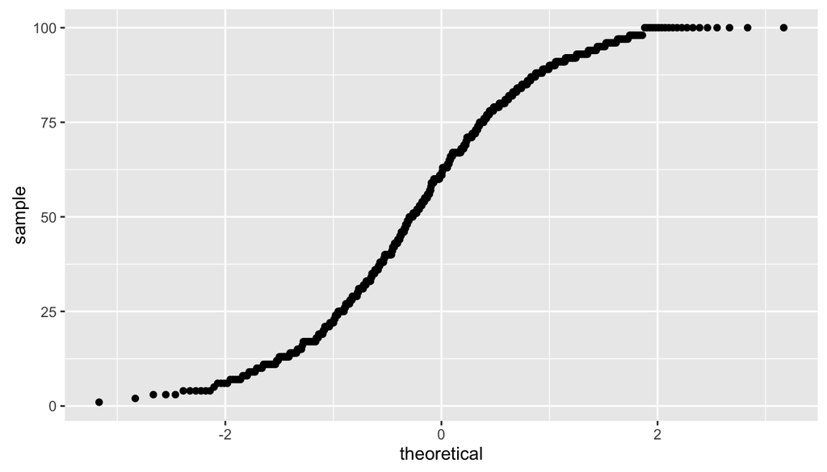

```r
ggplot(data = movies, mapping = aes(sample = movies$critics_score)) + stat_qq() # normal probability plot for critics score
```

Let’s also do the same with our second variable of interest, the audience score.

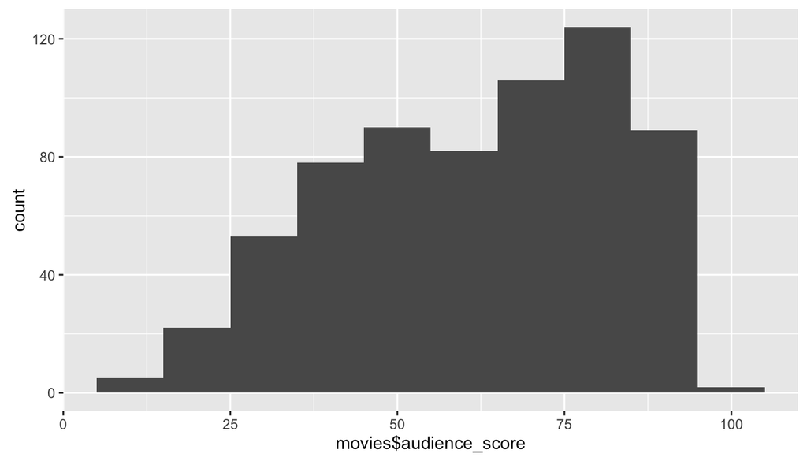

```r
ggplot(data = movies, aes(x = movies$audience_score)) + geom_histogram(binwidth = 10) #histogram of audience score
```

Again, let’s observe that, while we do have a unimodal peak, we also have some left skewing in the data, which suggests that our median will be larger than the mean score. Let’s now calculate our summary statistics for audience score.

```r
summary(movies$audience_score)
```

```
##    Min. 1st Qu.  Median    Mean 3rd Qu.    Max.
##   11.00   46.00   65.00   62.36   80.00   97.00
```

Notice that, for the audience score, their median score is higher than that of the critics, but the difference is not as large. Also, for the audience score, note that no audience score goes above 97, whereas critics do rate movies up until 100. Moreover, the third quartile is lower for the audience than for critics.

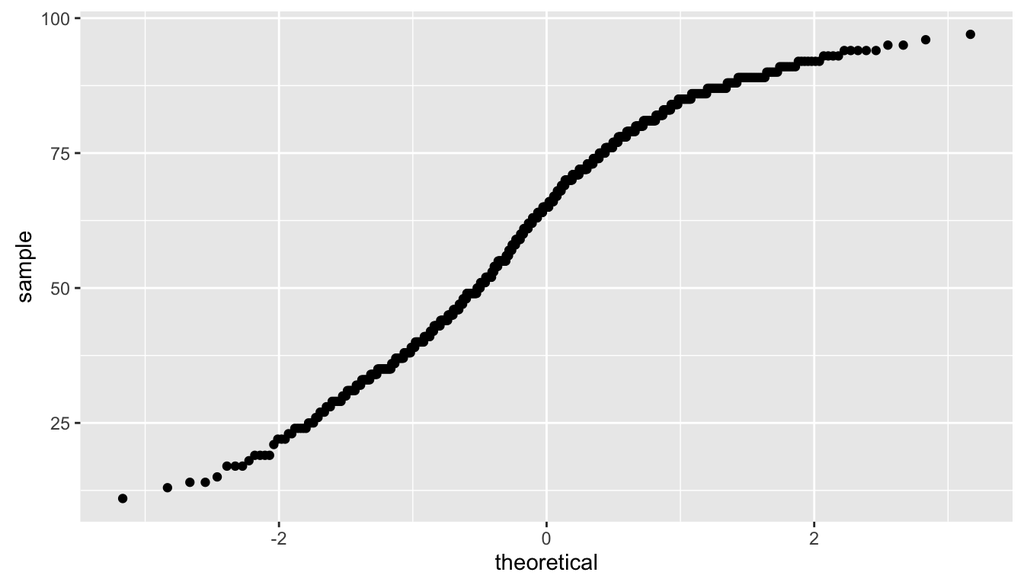

```r
ggplot(data = movies, mapping = aes(sample = movies$audience_score)) + stat_qq() # normal probability plot for audience score
```

The normal probability plot also shows a bit of left tail, or skew, which reflects the findings of the histogram. Moreover, from looking at this theoretical plot, we notice that the data is not necessarily follow a normal distribution because it does not have a straight line.

Let’s also do a side-by-side boxplot for the two groups to compare how they stack up against each other.

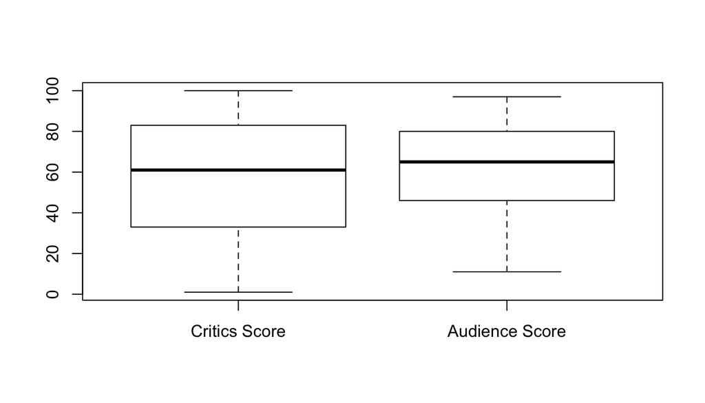

```r
boxplot(movies$critics_score, movies$audience_score, names = c("Critics Score", "Audience Score"))
```

We notice that, for critics, there’s a more of a spread, which is what we saw in the summary statistics, than the audience. In essence, there’s a larger variability between the two groups, as evidenced by the length of the boxes (i.e., the IQR range) and the whiskers. For example, notice that the lower whisker for critics score extends much lower than that of the audience, whereas the upper whiskers are not too far off from each other. The medians for audience and critics score are also different, but they do not appear to be too far off from each other, as represented in the summary statistics as well.

Let’s also take a look at the histogram and normal probability plot for run time, one of our variables of interest, in addition to a boxplot and summary statistics.

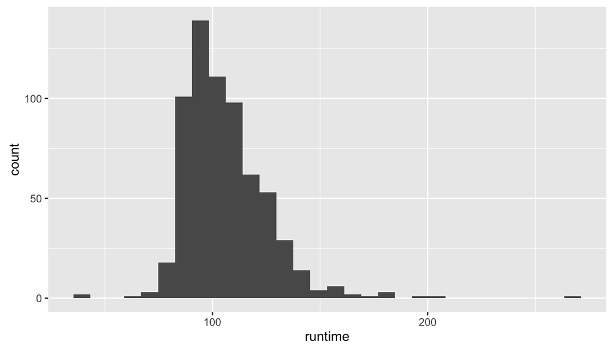

```r
ggplot(data = movies, mapping = aes(x = runtime)) + geom_histogram()
```

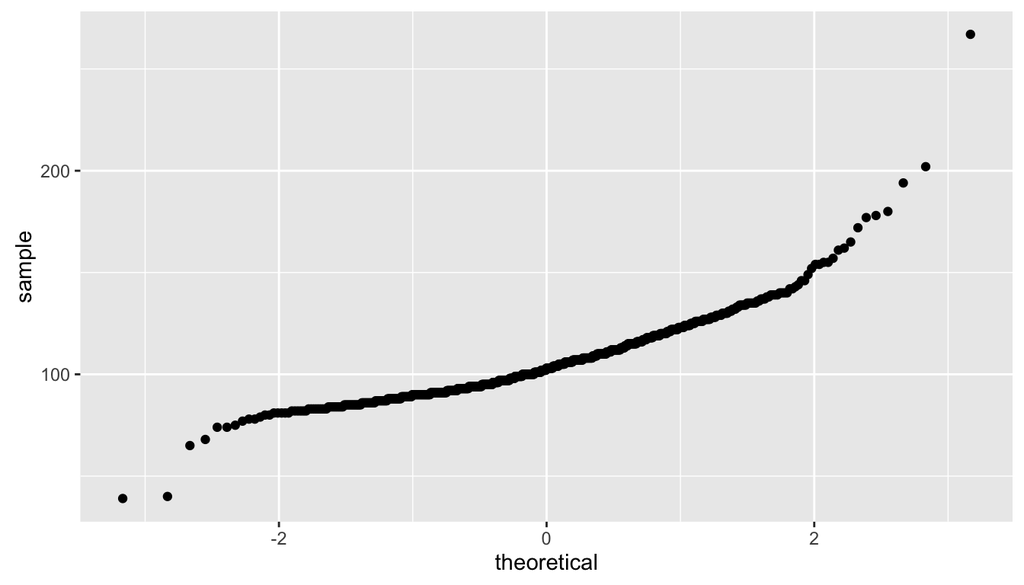

```r
ggplot(data = movies, mapping = (aes(sample = runtime)))+stat_qq()
```

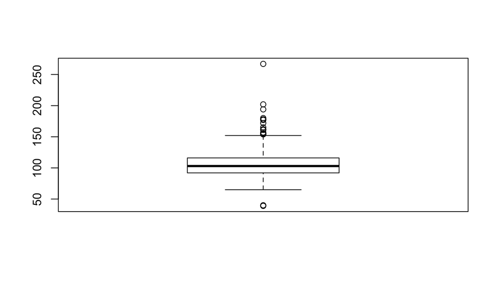

```r
boxplot(movies$runtime, names = c("Run time"))
```

```r
summary(movies$runtime)
```

```
##    Min. 1st Qu.  Median    Mean 3rd Qu.    Max.    NA's
##    39.0    92.0   103.0   105.8   115.8   267.0       1
```

Note here that the data is not entirely linear in the normal probability plot and histogram, which suggests that there is not entirely a normal distribution of the data. We’ve also got a bit of a right tail, suggesting that there is a right skew and possibly an outlier in the data when it comes to run time. This is also reflected in our box plot. Let’s also summarize this data, which shows we’ve got the shortest film in our set at 39 minutes, with 50% of films being 103 minutes or below. We also seem to have a few films outside of our upper whisker, which is reflected in the right tail.

Finally, let’s do a brief data exploration of our categorical variables of interest: best actress win, best picture win, best director win, and top 200.

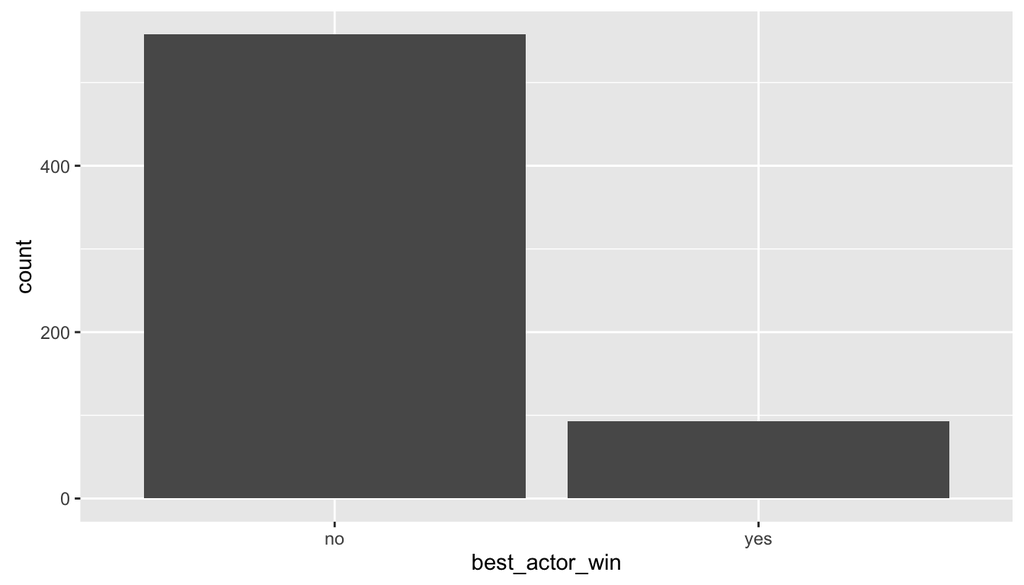

```r
ggplot(data = movies, mapping = aes(x = best_actor_win)) + geom_bar()
```

```r
summary(movies$best_actor_win)
```

```
##  no yes
## 558  93
```

```r
summarise(best_actor_prop = sum(best_actor_win == "yes")/n(), best_actor_total = sum(best_actor_win == "yes"), movies)
```

```
## Source: local data frame [1 x 2]
##
##   best_actor_prop best_actor_total
##             <dbl>            <int>
## 1       0.1428571               93
```

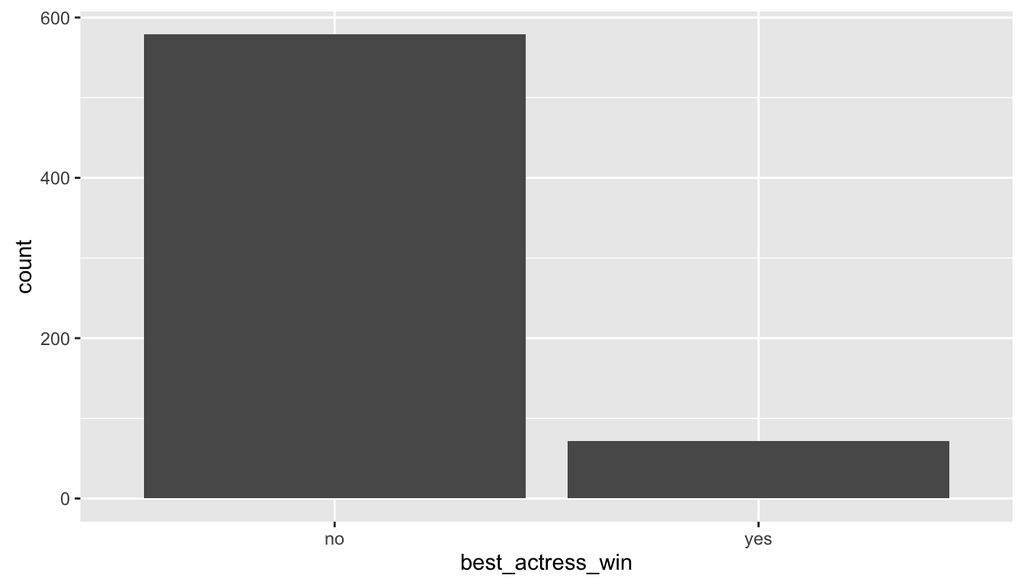

```r
ggplot(data = movies, mapping = aes(x = best_actress_win)) + geom_bar()
```

```r
summary(movies$best_actress_win)
```

```
##  no yes
## 579  72
```

```r
summarise(best_actress_prop = sum(best_actress_win == "yes")/n(), best_actress_total = sum(best_actress_win == "yes"), movies)
```

```
## Source: local data frame [1 x 2]
##
##   best_actress_prop best_actress_total
##               <dbl>              <int>
## 1         0.1105991                 72
```

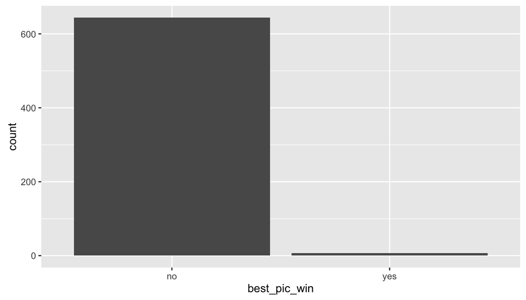

```r
ggplot(data = movies, mapping = aes(x = best_pic_win)) + geom_bar()
```

```r
summary(movies$best_pic_win)
```

```
##  no yes
## 644   7
```

```r
summarise(best_pic_prop = sum(best_pic_win == "yes")/n(), best_pic_total = sum(best_pic_win == "yes"), movies)
```

```
## Source: local data frame [1 x 2]
##
##   best_pic_prop best_pic_total
##           <dbl>          <int>
## 1    0.01075269              7
```

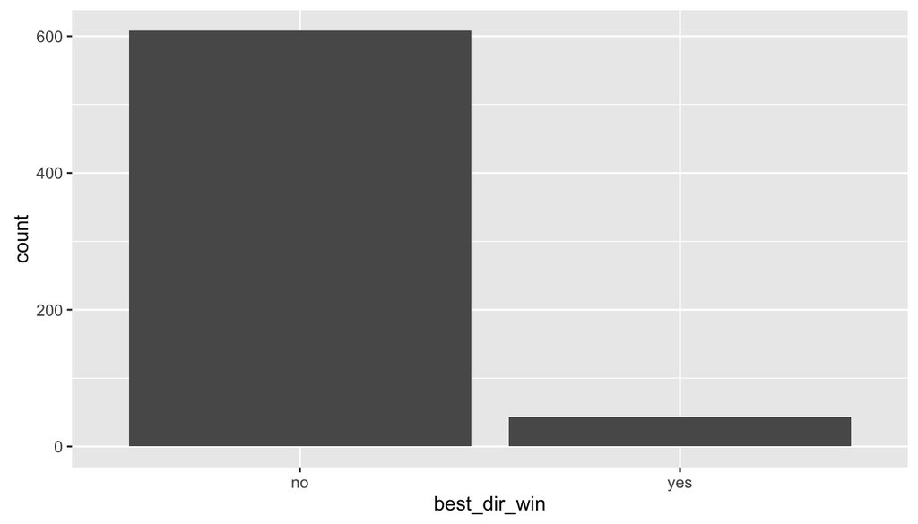

```r
ggplot(data = movies, mapping = aes(x = best_dir_win)) + geom_bar()
```

```r
summary(movies$best_dir_win)
```

```
##  no yes
## 608  43
```

```r
summarise( best_dir_prop = sum(best_dir_win == "yes")/n(), best_dir_total = sum(best_dir_win == "yes"), movies)
```

```
## Source: local data frame [1 x 2]
##
##   best_dir_prop best_dir_total
##           <dbl>          <int>
## 1    0.06605223             43
```

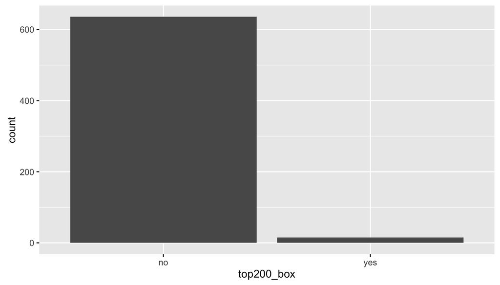

```r
ggplot(data = movies, mapping = aes(x = top200_box)) + geom_bar()
```

```r
summary(movies$top200_box)
```

```
##  no yes
## 636  15
```

```r
summarise(top200_prop = sum(top200_box == "yes")/n(), top200_total = sum(top200_box == "yes"), movies)
```

```
## Source: local data frame [1 x 2]
##
##   top200_prop top200_total
##         <dbl>        <int>
## 1  0.02304147           15
```

As for the other categorical variables of if the film contains an actor, actress, or director who had recieved the respective ‘best’ award for the Academy Awards, there is a higher proportion of best actor wins (14%), then best actress (11%), followed by directors (6%). Finally, for our box office top 200 categorical variable, our sample includes about 2.3% of those movies.

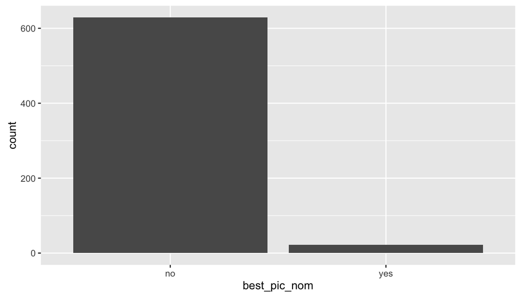

```r
ggplot(data = movies, mapping = aes(x = best_pic_nom)) + geom_bar()
```

```r
summary(movies$best_pic_nom)
```

```
##  no yes
## 629  22
```

```r
summarise(best_pic_prop = sum(best_pic_nom == "yes")/n(), best_pic_nom = sum(best_pic_nom == "yes"), movies)
```

```
## Source: local data frame [1 x 2]
##
##   best_pic_prop best_pic_nom
##           <dbl>        <int>
## 1    0.03379416           22
```

When we see best pic nominated films, we’re dealing with a slightly higher percentage in the sample (around 3.4%), and so it might be worthwhile to use nomination more than win for thinking through popularity.